# Climbing Insights

Ian McDonald

Intro:

Welcome to my data science project. The data I chose to examine for this was a dataset that was scraped from 8a.nu. This is a popular website used by rock climbers. 8a.nu offers a feature that allows users to log the climbs that they have completed. Additionally there is user data included that has information about the climbers who logged these climbs. As a rock climber myself, this data interested me as I hoped to learn a little bit more about climbers, but also learn more about climbing areas and individual climbs.

Setup

loading libraries that we used

```r
library("tidyverse")
```

```r
library("RSQLite")
library("ggplot2")
library("RColorBrewer")
```

Creating a connection to the database we will be using. This database houses all of the user entered data the was taken from 8a.nu This data is all self reported data. Due to this there will be some level of inaccuracy and potentially wrong data that users have entered. This will cause there to be lots of outliers in some of the data.

Download data from https://www.kaggle.com/dcohen21/8anu-climbing-logbookg

```r
con <- dbConnect(RSQLite::SQLite(), "database.sqlite")
dbListTables(con)
```

```
## [1] "ascent" "grade"  "method" "user"
```

```r
ascents <- dbGetQuery(con, "SELECT * FROM ASCENT;")
grades <- dbGetQuery(con, "SELECT * FROM GRADE");
methods <- dbGetQuery(con, "SELECT * FROM METHOD;")
users <- dbGetQuery(con, "SELECT * FROM USER;")
```

Time to Clean and Tidy Data

First lets look at the Users Dataframe we created.

```r
dim(users)
```

```
## [1] 62593    22
```

```r
colnames(users)
```

```
##  [1] "id"           "first_name"   "last_name"    "city"         "country"
##  [6] "sex"          "height"       "weight"       "started"      "competitions"
## [11] "occupation"   "sponsor1"     "sponsor2"     "sponsor3"     "best_area"
## [16] "worst_area"   "guide_area"   "interests"    "birth"        "presentation"
## [21] "deactivated"  "anonymous"
```

Cleaning user dataframe. First we take all values in the height and weight and started columns and replace them with N/A value Then we need to take all empty valus in the remaining tables string fields and replace empty strings with na values

Finally we create a tibble that will have the data we are going to be most interested in from this table.

```r
colnames(users)[colnames(users) == 'id'] <- 'user_id'
users[, 7:9][users[,7:9]==0] <- NA
users[, 10:20][users[,10:20]==""] <- NA
userInfo <- dplyr::tibble(id=users$user_id, height=users$height, weight=users$weight, city=users$city, country=users$country, year_started=users$started, occupation=users$occupation, birthday=users$birth)
```

Next Looking at the ascent table A lot of data in this table is specific to what we are deciding to look at. We will need to clean a lot of this data.

```r
dim(ascents)
```

```
## [1] 4111877      28
```

```r
colnames(ascents)
```

```
##  [1] "id"                   "user_id"              "grade_id"
##  [4] "notes"                "raw_notes"            "method_id"
##  [7] "climb_type"           "total_score"          "date"
## [10] "year"                 "last_year"            "rec_date"
## [13] "project_ascent_date"  "name"                 "crag_id"
## [16] "crag"                 "sector_id"            "sector"
## [19] "country"              "comment"              "rating"
## [22] "description"          "yellow_id"            "climb_try"
## [25] "repeat"               "exclude_from_ranking" "user_recommended"
## [28] "chipped"
```

This code is to replace empty values with NA in certain rows and to remove other rows from the data frame that we wont be using

```r
ascents[, 4][ascents[,4]==""] <- NA
ascents[, 14][ascents[,14]==""] <- NA
ascents[, 15][ascents[,15]==0] <- NA
ascents[, 16][ascents[,16]==""] <- NA
ascents[, 17][ascents[,17]==0] <- NA
ascents[, 18][ascents[,18]==""] <- NA
ascents[, 19][ascents[,19]==""] <- NA
ascents[, 20][ascents[,20]=="\n"] <- NA
ascents$raw_notes <- NULL
```

##Next Looking at the grades table The grades table holds information used to convert between the differnet climbing systems. There are 4 main climbing rating systems.

```r
dim(grades)
```

```
## [1] 83 14
```

```r
colnames(grades)
```

```
##  [1] "id"                    "score"                 "fra_routes"
##  [4] "fra_routes_input"      "fra_routes_selector"   "fra_boulders"
##  [7] "fra_boulders_input"    "fra_boulders_selector" "usa_routes"
## [10] "usa_routes_input"      "usa_routes_selector"   "usa_boulders"
## [13] "usa_boulders_input"    "usa_boulders_selector"
```

```r
grades[, 1:14][grades[,1:14]==0] <- NA
```

Time to clean the last table the method table The method table holds information on the method of climbing done. In climbing there are different style of climbing based on certain aspects such as if you have climbed a route before. This table helps us assign a type to each climb that is logged.

```r
dim(methods)
```

```
## [1] 5 4
```

```r
colnames(methods)
```

```
## [1] "id"        "score"     "shorthand" "name"
```

```r
methods$name <- as.factor(methods$name)
levels(methods$name)
```

```
## [1] "Flash"    "Onsight"  "Redpoint" "Toprope"
```

Early Exploration

The ascents table has a lot of logged climbs in it. Lets look at this data Plot number of climbs logged at each different grade as a bar chart

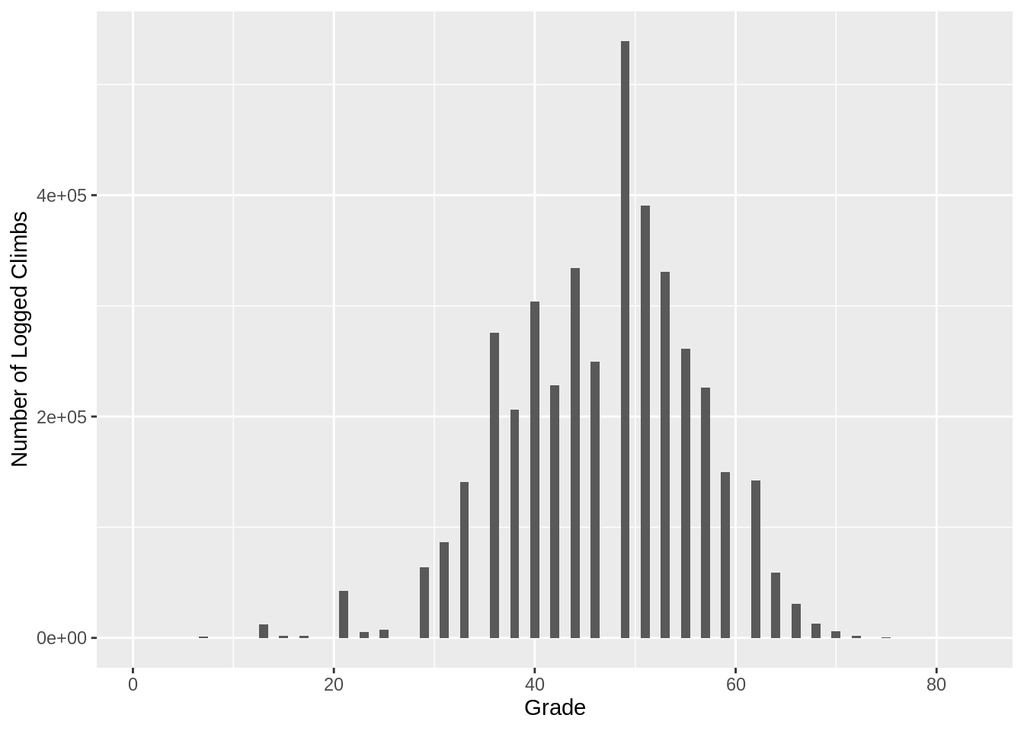

```r
plot <- ggplot(ascents, aes(x=grade_id)) + geom_bar() + xlab("Grade") + ylab("Number of Logged Climbs")
plot
```

Look at the hardest climb each user has done and the year they started climbing

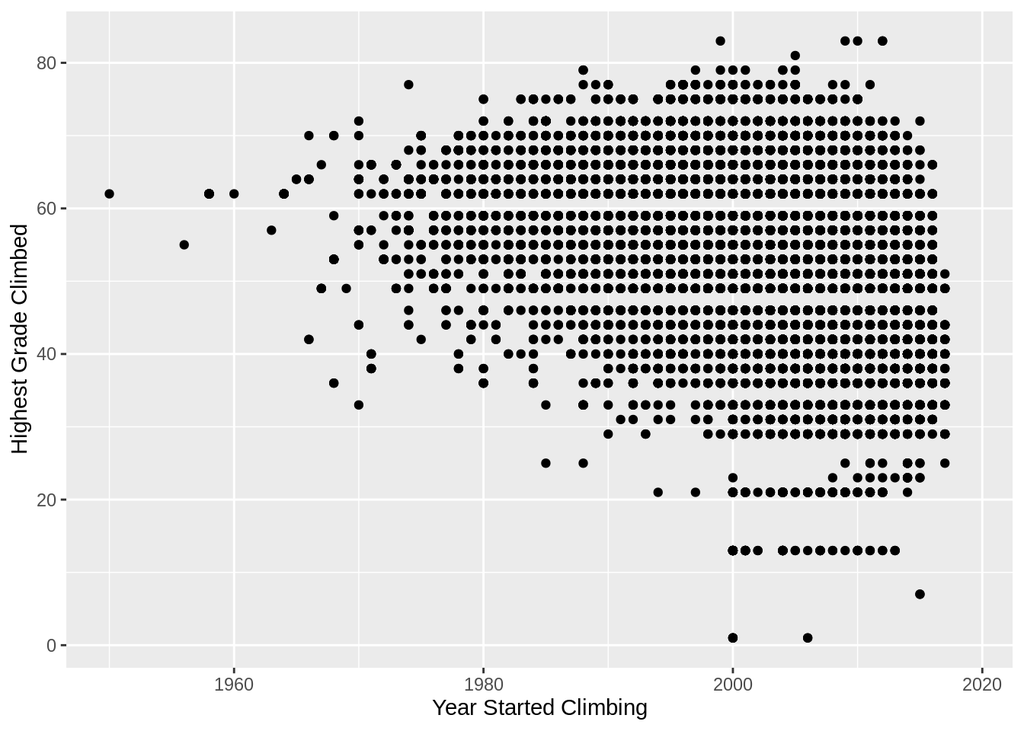

```r
hardestClimb <- ascents %>% group_by(user_id) %>% filter(grade_id == max(grade_id))
hardestWithYear <- merge(hardestClimb,users, by="user_id")
startPlot <- ggplot(hardestWithYear, aes(x=started,y=grade_id)) + geom_point() +  xlim(1950, 2019) + xlab("Year Started Climbing") + ylab("Highest Grade Climbed")
startPlot
```

Now lets look at the number of users from each of the top 10 countries

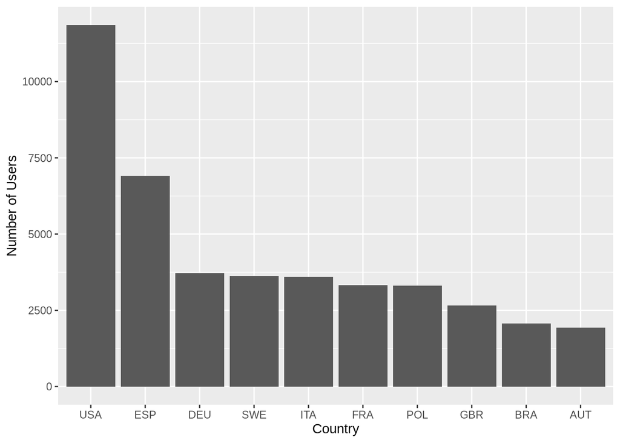

```r
usersPerCountry <- count(users, country)
usersPerCountry <- usersPerCountry[order(usersPerCountry$n, decreasing = TRUE),]
usersPerCountry$country <- factor(usersPerCountry$country, levels = usersPerCountry$country)
usersPerCountry <- head(usersPerCountry, 10)
plotP <- ggplot(usersPerCountry, aes(country, n)) + geom_col() + ylab("Number of Users") + xlab("Country")
plotP
```

Research Questions: Finally some things I would like to look into are things like the relationship between size and climbing ability. It is often thought that height and weight are major factors in ones climbing ability and from personal experience this can be true. However often people use height as an excuse so I would like to look into how true this is. Finally I would also like to look into how experience can effect hardest grade climbed. This is an important factor that often can’t be gained quickly as climbing hard outdoors requires knowledge and experience, so I would expect it to play a major role and would like to investigate things more.